# ECON 5181 Assignment 2

## Q2. Logistic regression

In class, we mentioned that neural network without the hidden layer will degenerate to a logistic regression model. In this exercise, we explore this frequently used nonlinear model in predicting a binary response $Y_i \in \{0, 1\}$.

The model has the form: $$Pr(Y = 1|X=x;\beta) = \frac{\exp (x'\beta)}{1 + \exp(x'\beta)}$$

#### 1. Write down the log-likelihood function $l(b)$ for observing $\{x_i, y_i\}, i = 1, \cdots, n$ in the training sample

$$l(\beta) = \sum_{i=1}^{n} \left[ y_i \ln(h_{\beta}(x_i)) + (1 - y_i) \ln(1 - h_{\beta}(x_i)) \right]$$

where $h_{\beta}(x_i) = \frac{\exp (x_i'\beta)}{1 + \exp(x_i'\beta)}$

#### 2. We estimate the model by maximum likelihood. Is the log-likelihood function convex? Justify your answer.

$$Max_{\beta_{1},\dots,\beta_{M}} - \sum_{i=1}^{n} \left[ y_i \ln(h_{\beta}(x_i)) + (1 - y_i) \ln(1 - h_{\beta}(x_i)) \right]$$$$\frac{\partial l}{\partial \beta_{m}} = - \sum_{i=1}^{n} x_{im}(y_i - h_{\beta}(x_i))$$$$\frac{\partial^{2} l}{\partial (\beta_{m})^{2}} = \sum_{i=1}^{n} x_{im}^{2}h_{\beta}(x_i)(1 - h_{\beta}(x_i)) $$$$\frac{\partial^{2} l}{\partial \beta_{m} \partial \beta_{n}} = \sum_{i=1}^{n} x_{im}x_{in}h_{\beta}(x_i)(1 - h_{\beta}(x_i))\quad (m\neq j)$$

Hessian matrix of $l(b)$ is

$$h_{\beta}(x_i)(1 - h_{\beta}(x_i))\begin{bmatrix} \sum_{i=1}^{n}x_{i1}^{2} & \sum_{i=1}^{n}x_{i1}x_{i2} & \dots & \sum_{i=1}^{n}x_{i1}x_{im}\\ \sum_{i=1}^{n}x_{i2}x_{i1} & \sum_{i=1}^{n}x_{i2}^{2} & \dots & \sum_{i=1}^{n}x_{i2}x_{im}\\ \dots & \dots & \dots & \dots\\ \sum_{i=1}^{n}x_{im}x_{i1} & \sum_{i=1}^{n}x_{im}x_{i1} & \dots & \sum_{i=1}^{n}x_{im}^{2}\\ \end{bmatrix}_{m\times m}$$

=$$h_{\beta}(x_i)(1 - h_{\beta}(x_i))X^{'}X$$

where $X$ is

$$\begin{bmatrix} x_{11} & x_{12} & \dots & x_{1m}\\ x_{21} & x_{22} & \dots & x_{2m}\\ \dots & \dots & \dots & \dots\\ x_{n1} & x_{n2} & \dots & x_{nm}\\ \end{bmatrix}_{n\times m}$$

Since $h_{\beta}(x_i)(1 - h_{\beta}(x_i))$ is always positive, the Hessian matrix is positive semi-definite. Thus, the log-likelihood function is convex.

#### 3. We use gradient descent to solve the optimization problem. Derive the gradient $\nabla l(b)$. Program a procedure for estimating a logistic regression model using gradient descent.

# Gradient of the log-likelihood function

```python
def logistic_regression(X, Y, alpha, tol=1e-5):
    '''
    logit regression using gradient descent
    :param X: n x m matrix of features
    :param Y: n x 1 matrix of labels
    :param alpha: learning rate
    :param tol: tolerance level
    :return: estimated coefficients
    '''
    n, m = X.shape
    beta = np.random.normal(0, 1, m)
    hs = []
    iter = 0
    while True:
        iter += 1
        h = 1/(1 + np.exp(-X @ beta))
        gradient = X.T @ (h - Y)
        # since is negative log-likelihood, we want to minimize it
        beta_new = beta - alpha * gradient/n
        hs.append(-np.sum(Y * np.log(h) + (1 - Y) * np.log(1 - h))/n)
        if np.linalg.norm(beta_new - beta) < tol:
            break
        if iter > 2000:
            break
        beta = beta_new
    return beta, hs
```

Credit scoring is a classic problem in classification. When a bank receives a loan application, based on the applicant’s profile the bank has to make a decision regarding whether to go ahead with the loan approval or not. Such decisions ideally should rely on an assessment of default risk.

We turn to the widely used German credit data to investigate binary classification using logistic regression model and others. Data and code are on Blackboard in `credit.zip`.

The dataset consists of 1000 records of approved loan applications. The dependent variable for your purpose is `default`, which codes whether the credit contract has been complied with (0) or not (1). Other variables in the dataset are borrower and loan characteristics, including a person's prior credit history.

Data is downloaded from [UCI Machine Learning Repository](https://archive.ics.uci.edu/ml/datasets/Statlog+%28German+Credit+Data%29). Some data cleaning needs to be done before we can comfortably work with it...

Dealing with missing values

```python
data = pd.read_csv('../data/credit/credit.csv')
# check data briefly
data
```

|  | Default | checkingstatus1 | duration | history | purpose | amount | savings | employ | installment | status | ... | residence | property | age | otherplans | housing | cards | job | liable | tele | foreign |
| --- | --- | --- | --- | --- | --- | --- | --- | --- | --- | --- | --- | --- | --- | --- | --- | --- | --- | --- | --- | --- | --- |
| 0 | 0 | A11 | 6 | A34 | A43 | 1169 | A65 | A75 | 4 | A93 | ... | 4 | A121 | 67 | A143 | A152 | 2 | A173 | 1 | A192 | A201 |
| 1 | 1 | A12 | 48 | A32 | A43 | 5951 | A61 | A73 | 2 | A92 | ... | 2 | A121 | 22 | A143 | A152 | 1 | A173 | 1 | A191 | A201 |
| 2 | 0 | A14 | 12 | A34 | A46 | 2096 | A61 | A74 | 2 | A93 | ... | 3 | A121 | 49 | A143 | A152 | 1 | A172 | 2 | A191 | A201 |
| 3 | 0 | A11 | 42 | A32 | A42 | 7882 | A61 | A74 | 2 | A93 | ... | 4 | A122 | 45 | A143 | A153 | 1 | A173 | 2 | A191 | A201 |
| 4 | 1 | A11 | 24 | A33 | A40 | 4870 | A61 | A73 | 3 | A93 | ... | 4 | A124 | 53 | A143 | A153 | 2 | A173 | 2 | A191 | A201 |
| ... | ... | ... | ... | ... | ... | ... | ... | ... | ... | ... | ... | ... | ... | ... | ... | ... | ... | ... | ... | ... | ... |
| 995 | 0 | A14 | 12 | A32 | A42 | 1736 | A61 | A74 | 3 | A92 | ... | 4 | A121 | 31 | A143 | A152 | 1 | A172 | 1 | A191 | A201 |
| 996 | 0 | A11 | 30 | A32 | A41 | 3857 | A61 | A73 | 4 | A91 | ... | 4 | A122 | 40 | A143 | A152 | 1 | A174 | 1 | A192 | A201 |
| 997 | 0 | A14 | 12 | A32 | A43 | 804 | A61 | A75 | 4 | A93 | ... | 4 | A123 | 38 | A143 | A152 | 1 | A173 | 1 | A191 | A201 |
| 998 | 1 | A11 | 45 | A32 | A43 | 1845 | A61 | A73 | 4 | A93 | ... | 4 | A124 | 23 | A143 | A153 | 1 | A173 | 1 | A192 | A201 |
| 999 | 0 | A12 | 45 | A34 | A41 | 4576 | A62 | A71 | 3 | A93 | ... | 4 | A123 | 27 | A143 | A152 | 1 | A173 | 1 | A191 | A201 |

1000 rows × 21 columns

Read data and create some interesting variables. Helpful to look at the codebook and figure out the meaning of original labels

```python
# divide the features into categorical and numerical
numerical_features = []
categorical_features = []
df_labels = data['Default']
for col in data.columns[1:]:
    if data[col].dtype == 'object':
        categorical_features.append(col)
    else:
        numerical_features.append(col)
numerical_features, categorical_features
```

```
(['duration', 'amount', 'installment', 'residence', 'age', 'cards', 'liable'],
 ['checkingstatus1',
  'history',
  'purpose',
  'savings',
  'employ',
  'status',
  'others',
  'property',
  'otherplans',
  'housing',
  'job',
  'tele',
  'foreign'])
```

```python
# deal with missing values: no missing values
data.isnull().sum()
```

```
Default            0
checkingstatus1    0
duration           0
history            0
purpose            0
amount             0
savings            0
employ             0
installment        0
status             0
others             0
residence          0
property           0
age                0
otherplans         0
housing            0
cards              0
job                0
liable             0
tele               0
foreign            0
dtype: int64
```

```python
# do one-hot encoding for categorical variables
one_hot = pd.get_dummies(data[categorical_features])
# do standardization for numerical variables
numerical_features = data[numerical_features].apply(lambda x: (x - x.mean())/x.std())
df_features = pd.concat([numerical_features, one_hot], axis=1)
```

#### 4. Choose a reasonable step-size $\alpha$. Plot the value of the objective function on each iteration of gradient descent, with the iteration number on the horizontal axis and the objective value on the vertical axis.

Make sure to include axis labels and a title for your plot. Draw the plot described above for three cases: too small $\alpha$, reasonable $\alpha$, and too big $\alpha$. You should be able to see the objective function decreases quickly and then becomes stable if the scale of $\alpha$ is reasonable.

```python
# def loader(features, labels, batch_size):
#     num_examples = len(features)
#     indices = list(range(num_examples))
#     random.shuffle(indices)
#     for i in range(0, num_examples, batch_size):
#         batch_indices = indices[i: min(i + batch_size, num_examples)]
#         yield features[batch_indices], labels[batch_indices]
#
# data_loader = loader(df_features.values, df_labels.values, 32)
# X, Y = next(data_loader)
# X.shape, Y.shape
```

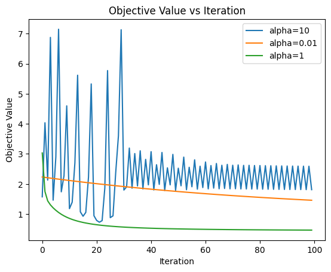

```python
alpa_list = [10, 0.01, 1]
def plot_results(features, labels, alpha_list):
    for alpha in alpha_list:
        beta, values = logistic_regression(features, labels, alpha)
        plt.plot(values[:100], label='alpha={}'.format(alpha))
        plt.legend()
        plt.xlabel('Iteration')
        plt.ylabel('Objective Value')
        plt.title('Objective Value vs Iteration')

plot_results(df_features.values, df_labels.values, alpa_list)
```

for alpha = 10, the learning rate too large that the objective value jumps around and does not converge for alpha = 0.01, the learning rate is too small that the objective value decreases very slowly for alpha = 1, the learning rate is reasonable that the objective value decreases quickly and then becomes stable

#### 5. Use the reasonable $\alpha$ you get and run the gradient descent on the German credit data. Report the number of iterations that are required for the algorithm to converge. Report the estimated regression coefficients. Also, implement logistic regression using R package `glm`. Does your programmed procedure agree with the canned routine?

```python
beta, values = logistic_regression(df_features.values, df_labels.values, 1)
```

```python
from sklearn.linear_model import LogisticRegression
from sklearn.model_selection import train_test_split, GridSearchCV
from sklearn.metrics import accuracy_score

X_train, X_test, y_train, y_test = train_test_split(df_features.values, df_labels.values, test_size=0.2, random_state=0)
model = LogisticRegression()
model.fit(X_train, y_train)
coef = model.coef_
y_pred = model.predict(X_test)
```

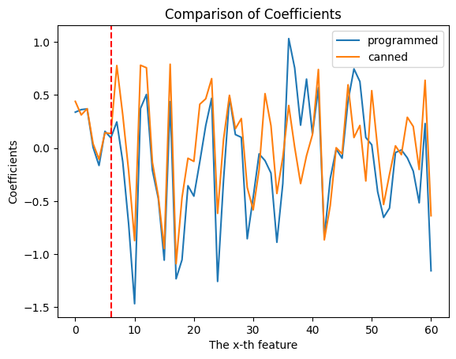

```python
beta = beta.reshape((61, 1))
coef = coef.reshape((61, 1))
plt.plot(beta, label='programmed')
plt.plot(coef, label='canned')
plt.legend()
plt.title('Comparison of Coefficients')
plt.xlabel('The x-th feature')
plt.ylabel('Coefficients')
plt.axvline(x=6, color='r', linestyle='--')
```

Here is a explainantion of the difference between my approach and the example in assignment2.html

I do standardazation for numerical variables since we are using gradient descent and there is a log function in our objective function.

In case of overflow, making sure the data is of the same scale is important.

#### 6. There are lots of regressors in the data set, making it hard to interpret the fitted model. We use LASSO penalty to do variable selection. Write down the objective function for the log-likelihood with a $L_1$ penalty, $\lambda$ being the penalty parameter as usual.

$$Min_{\beta_{1},\dots,\beta_{M}} \sum_{i=1}^{n} \left[ y_i \ln(h_{\beta}(x_i)) + (1 - y_i) \ln(1 - h_{\beta}(x_i)) \right] + \lambda \sum_{m=1}^{M}|\beta_{m}|$$

#### 7. Use `glmnet` or `gamlr` to estimate the LASSO logistic regression. Report the selected $\lambda$ using cross validation. How many variables are selected by LASSO under CV, AICc, BIC, and AIC criteria?

```
Best lambda: 1.9179102616724868
```

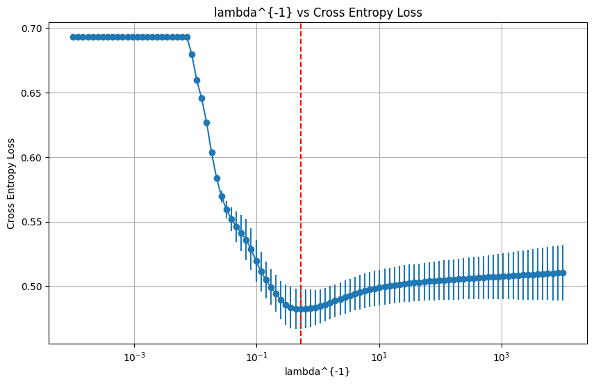

```python
alphas = np.logspace(-4, 4, 100)
model = LogisticRegression()
model = LogisticRegression(penalty='l1', solver='liblinear')
grid_search = GridSearchCV(model, {'C': alphas}, scoring='neg_log_loss', cv=5)
grid_search.fit(X_train, y_train)
cv_results = grid_search.cv_results_
mean_test_scores = -cv_results['mean_test_score']
std_test_scores = cv_results['std_test_score']

plt.figure(figsize=(10, 6))
plt.errorbar(alphas, mean_test_scores, yerr=std_test_scores, fmt='-o')
plt.xscale('log')
plt.xlabel('lambda^{-1}')
plt.ylabel('Cross Entropy Loss')
plt.title('lambda^{-1} vs Cross Entropy Loss')
plt.grid(True)
plt.axvline(x=grid_search.best_params_['C'], color='r', linestyle='--')
print("Best lambda:", 1/grid_search.best_params_['C'])
```

```python
model = LogisticRegression()
model = LogisticRegression(penalty='l1', solver='liblinear', C=grid_search.best_params_['C'])
model.fit(X_train, y_train)
selected_features = np.sum(model.coef_ != 0)
selected_features
```

```
36
```